# Malfunction Original HW Code

Jimmy Erkens

2023-10-25

# 1 Challenges!

1. I always forget how finicky `ggplot2` is with manual prediction/confidence intervals when not using `geom_smooth()`. I had to look up the documentation.
2. I originally made a variable called “warning” that would either be NULL or print out my warning message. I realized using `print()` would be more efficient and less confusing.
3. I wanted to work out `geom_ribbon()` instead of `geom_line()`, and my `predict()` function wasn’t working out until I conceded on using `geom_line()`.

# 2 Libaries

```r
library(tidyverse)
library(curl)
```

# 3 Question 1

We’re going to write a simple function here to perform a proportion test, for one or two samples, both one/two tailed, in either direction.

```r
Z.prop.test <- function(p1, n1, p0, alternative = "two.sided", p2 = NULL, n2 = NULL, conf.level = 0.95){
  # note we use equals inside functions
  result_list <- NULL # just initializing some things\

  test_stat = NULL # Initialize some more vectors
  p_value = NULL
  conf_interval = NULL
  alpha = (1 - conf.level)/2

  # two sample situation
  if (is.null(p2) == F & is.null(n2) == F){
    if((((n1*p1 < 5) | ((1-p1) * n1 < 5)) | ((n2*p2 < 5) | ((1-p2) * n2 < 5)))){
    print("Warning! Model assumptions not met, caution against interpretations")
    }
    phat = ((p1*n1) + (p2*n2))/(n1 + n2) # the Ph in Ph.D stands for Phat
    # under null proportions are the same
    test_stat_var = (phat *(1-phat)) * ((1/n1) +(1/n2)) # variance formula
    test_stat = (p2 - p1)/(sqrt(test_stat_var)) # test stat is the same regardless of alternative
    conf_interval = c((p2-p1) + (qnorm(alpha/2) * sqrt(test_stat_var)),(p2-p1) + (qnorm(1 - alpha/2) * sqrt(test_stat_var)))
    # not messing around with one-sided conf.intervals not in this house
    if (alternative == "two.sided"){
      if (p2 >= p1){ # then our test_stat is nonnegative
        p_value = 2 * pnorm(p2-p1, mean = 0, sd = sqrt(test_stat_var), lower.tail = F) # two sided is just 2* one-sided
      }
      if(p2 < p1){ # then our test_stat is negative
        p_value = 2 * pnorm(p2-p1, mean = 0, sd = sqrt(test_stat_var), lower.tail = T)
      }
    }
    if (alternative == "greater"){ # then we're checking p2 > p1
      p_value = pnorm(p2-p1, mean = 0, sd = sqrt(test_stat_var), lower.tail = F)
    }
    if (alternative == "less"){ # then p2 < p1
      p_value = pnorm(p2-p1, mean = 0, sd = sqrt(test_stat_var), lower.tail = T)
    }
  }
  # one sample situation
  if (is.null(p2) == T | is.null(n2) == T){ # the same logic as above for two-sample
    if((n1*p1 < 5) | ((1-p1) * n1 < 5)){
    print("Warning! Model assumptions not met, caution against interpretations")
    }
    test_stat_var = (p0 * (1-p0)/n1)
    test_stat = (p1 - p0)/sqrt(test_stat_var)
    conf_interval = c((p1-p0) + (qnorm(alpha/2) * sqrt(test_stat_var)), (p1-p0) + (qnorm(1 -alpha/2) * sqrt(test_stat_var)))
    if (alternative == "two.sided"){
      if (p1 >= p0){ # then our test_stat is nonnegative
        p_value = 2 * pnorm(p1, mean = p0, sd = sqrt(test_stat_var), lower.tail = F) # two sided is just 2* one-sided
      }
      if(p1 < p0){ # then our test_stat is negative
        p_value = 2 * pnorm(p1, mean = p0, sd = sqrt(test_stat_var), lower.tail = T)
      }
    }
    if (alternative == "greater"){ # then we're checking p2 > p1
      p_value = pnorm(p1, mean = p0, sd = sqrt(test_stat_var), lower.tail = F)
    }
    if (alternative == "less"){ # then we're checking p2 < p1
      p_value = pnorm(p1, mean = p0, sd = sqrt(test_stat_var), lower.tail = T)
    }
  }
  result_list = list(test_stat, p_value, conf_interval)

  return(result_list)
}
```

Let’s test it out!

```r
# one sample
Z.prop.test(p1 = 0.5, n1 = 20, p0 = 0.6) # does it work
```

```
## [[1]]
## [1] -0.9128709
##
## [[2]]
## [1] 0.3613104
##
## [[3]]
## [1] -0.3455334  0.1455334
```

```r
Z.prop.test(p1 = 0.5, n1 = 5, p0 = 0.6) # does error message show?
```

```
## [1] "Warning! Model assumptions not met, caution against interpretations"
```

```
## [[1]]
## [1] -0.4564355
##
## [[2]]
## [1] 0.6480769
##
## [[3]]
## [1] -0.5910667  0.3910667
```

```r
Z.prop.test(p1 = 0.5, n1 = 5, p0 = 0.6, conf.level = 0.5) # we're really not confident lol
```

```
## [1] "Warning! Model assumptions not met, caution against interpretations"
```

```
## [[1]]
## [1] -0.4564355
##
## [[2]]
## [1] 0.6480769
##
## [[3]]
## [1] -0.3520289  0.1520289
```

```r
Z.prop.test(p1 = 0.5, n1 = 5, p0 = 0.6, alternative = "less") # does alternative work?
```

```
## [1] "Warning! Model assumptions not met, caution against interpretations"
```

```
## [[1]]
## [1] -0.4564355
##
## [[2]]
## [1] 0.3240384
##
## [[3]]
## [1] -0.5910667  0.3910667
```

```r
# two sample
Z.prop.test(p1 = 0.5, n1 = 10, p2 = 0.5, n2 = 10) # yeah it works
```

```
## [[1]]
## [1] 0
##
## [[2]]
## [1] 1
##
## [[3]]
## [1] -0.5011929  0.5011929
```

```r
Z.prop.test(p1 = 0.5, n1 = 20, p2 = 0.1, n2 = 30)
```

```
## [1] "Warning! Model assumptions not met, caution against interpretations"
```

```
## [[1]]
## [1] -3.158989
##
## [[2]]
## [1] 0.001583176
##
## [[3]]
## [1] -0.6838127 -0.1161873
```

```r
Z.prop.test(p1 = 0.5, n1 = 20, p2 = 0.1, n2 = 30, alternative = "less")
```

```
## [1] "Warning! Model assumptions not met, caution against interpretations"
```

```
## [[1]]
## [1] -3.158989
##
## [[2]]
## [1] 0.000791588
##
## [[3]]
## [1] -0.6838127 -0.1161873
```

```r
Z.prop.test(p1 = 0.5, n1 = 20, p2 = 0.1, n2 = 30, conf.level = 0.5)
```

```
## [1] "Warning! Model assumptions not met, caution against interpretations"
```

```
## [[1]]
## [1] -3.158989
##
## [[2]]
## [1] 0.001583176
##
## [[3]]
## [1] -0.5456605 -0.2543395
```

# 4 Question 2

We’re going to work a simple linear regression using `lm()`, it’s going to be beautiful.

```r
kamilar <- read_csv(curl("https://raw.githubusercontent.com/fuzzyatelin/fuzzyatelin.github.io/master/AN588_Fall21/KamilarAndCooperData.csv")) %>% filter(is.na(Brain_Size_Species_Mean) == F & is.na(MaxLongevity_m) == F); head(kamilar) # load in data
```

```
## # A tibble: 6 × 44
##   Scientific_Name             Family        Genus Species Brain_Size_Species_M…¹
##   <chr>                       <chr>         <chr> <chr>                    <dbl>
## 1 Allenopithecus_nigroviridis Cercopitheci… Alle… nigrov…                   58.0
## 2 Alouatta_caraya             Atelidae      Alou… caraya                    52.6
## 3 Alouatta_palliata           Atelidae      Alou… pallia…                   49.9
## 4 Alouatta_pigra              Atelidae      Alou… pigra                     51.1
## 5 Alouatta_seniculus          Atelidae      Alou… senicu…                   55.2
## 6 Aotus_azarai                Cebidae       Aotus azarai                    20.7
## # ℹ abbreviated name: ¹Brain_Size_Species_Mean
## # ℹ 39 more variables: Brain_Size_Female_Mean <dbl>, Brain_size_Ref <chr>,
## #   Body_mass_male_mean <dbl>, Body_mass_female_mean <dbl>,
## #   Mass_Dimorphism <dbl>, Mass_Ref <chr>, MeanGroupSize <dbl>,
## #   AdultMales <dbl>, AdultFemale <dbl>, AdultSexRatio <dbl>,
## #   Social_Organization_Ref <chr>, InterbirthInterval_d <dbl>, Gestation <dbl>,
## #   WeaningAge_d <dbl>, MaxLongevity_m <dbl>, LitterSz <dbl>, …
```

```r
# create the model
kamilarmodel <- lm(MaxLongevity_m ~ Brain_Size_Species_Mean, data = kamilar); summary(kamilarmodel)
```

```
##
## Call:
## lm(formula = MaxLongevity_m ~ Brain_Size_Species_Mean, data = kamilar)
##
## Residuals:
##     Min      1Q  Median      3Q     Max
## -198.27  -61.92  -17.78   56.16  331.36
##
## Coefficients:
##                         Estimate Std. Error t value Pr(>|t|)
## (Intercept)             248.9523    11.1111   22.41   <2e-16 ***
## Brain_Size_Species_Mean   1.2180     0.1101   11.06   <2e-16 ***
## ---
## Signif. codes:  0 '***' 0.001 '**' 0.01 '*' 0.05 '.' 0.1 ' ' 1
##
## Residual standard error: 90.91 on 126 degrees of freedom
## Multiple R-squared:  0.4928, Adjusted R-squared:  0.4887
## F-statistic: 122.4 on 1 and 126 DF,  p-value: < 2.2e-16
```

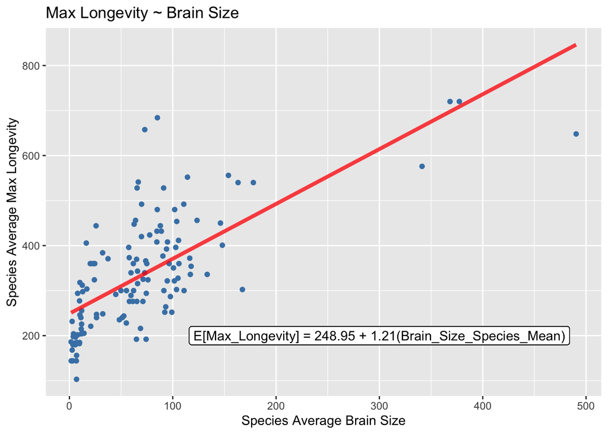

```r
# let's add some data for the sake of actually doing something
kamilar <- kamilar %>% mutate(linear_model = predict(kamilarmodel, kamilar))

kamilar %>% ggplot(aes(x = Brain_Size_Species_Mean, y = MaxLongevity_m)) +
  geom_point(color = "steelblue") + # this is the best R plot color <3
  geom_line(aes(x = Brain_Size_Species_Mean, y = linear_model),
            color = "red", size = 1.5, alpha = 0.75) +
  geom_label(aes(x = 300, y = 200, label = "E[Max_Longevity] = 248.95 + 1.21(Brain_Size_Species_Mean)")) +
  xlab("Species Average Brain Size") +
  ylab("Species Average Max Longevity") +
  ggtitle("Max Longevity ~ Brain Size")
```

```r
# this is the same stuff as above but w log
log_kamilar <- lm(MaxLongevity_m ~ log(Brain_Size_Species_Mean), data = kamilar); summary(log_kamilar)
```

```
##
## Call:
## lm(formula = MaxLongevity_m ~ log(Brain_Size_Species_Mean), data = kamilar)
##
## Residuals:
##      Min       1Q   Median       3Q      Max
## -187.712  -59.597   -8.055   50.013  294.276
##
## Coefficients:
##                              Estimate Std. Error t value Pr(>|t|)
## (Intercept)                    65.926     25.012   2.636  0.00945 **
## log(Brain_Size_Species_Mean)   72.859      6.449  11.298  < 2e-16 ***
## ---
## Signif. codes:  0 '***' 0.001 '**' 0.01 '*' 0.05 '.' 0.1 ' ' 1
##
## Residual standard error: 89.97 on 126 degrees of freedom
## Multiple R-squared:  0.5033, Adjusted R-squared:  0.4993
## F-statistic: 127.7 on 1 and 126 DF,  p-value: < 2.2e-16
```

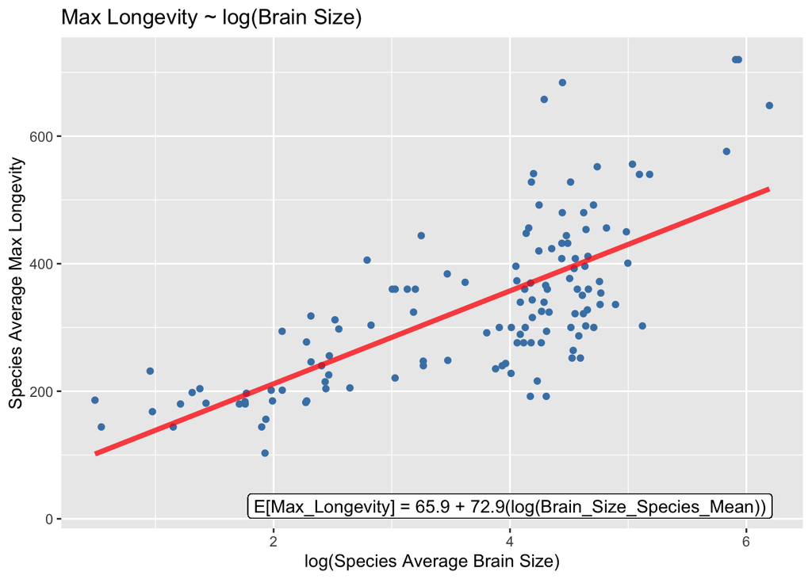

```r
kamilar <- kamilar %>% mutate(log_linear_model = predict(log_kamilar, kamilar))
kamilar %>% ggplot(aes(x = log(Brain_Size_Species_Mean), y = MaxLongevity_m)) +
  geom_point(color = "steelblue") + # this is the best R plot color <3
  geom_line(aes(x = log(Brain_Size_Species_Mean), y = log_linear_model),
            color = "red", size = 1.5, alpha = 0.75) +
  geom_label(aes(x = 4, y = 20, label = "E[Max_Longevity] = 65.9 + 72.9(log(Brain_Size_Species_Mean))")) +
  xlab("log(Species Average Brain Size)") +
  ylab("Species Average Max Longevity") +
  ggtitle("Max Longevity ~ log(Brain Size)")
```

Let’s interpret our terms! As the average brain size per species increases by 1, the estimated (not predicted!) average max longevity increases by 1.21 units! p < 2.2e-16, hence we have significant evidence to reject the null hypothesis that the slope value is 0. We have significant evidence there is a linear relationship between average species brain size and maximum longevity!  
For the log data, as log(average brain size per species) increases by 1, the estimated average mmax longevity increases by 72.859 units. p < 2.2e-16 hence we have significant evidence to reject the null hypotehsis that the slope value is 0. There is a linear relationship between log(average species brain size) and maximum longevity!

```r
kamilarconf90 <- predict(kamilarmodel, # first we need to generate our prediciton and confidence intervlas
                         new_data = as.data.frame(Brain_Size_Species_Mean = kamilar$Brain_Size_Species_Mean),
                         interval = "conf", level = 0.9) %>% as.data.frame()
kamilarpred90 <- predict(kamilarmodel,
                         new_data = as.data.frame(Brain_Size_Species_Mean = kamilar$Brain_Size_Species_Mean),
                         interval = "pred", level = 0.9) %>% as.data.frame()
logkamilarconf90 <- predict(log_kamilar,
                         new_data = as.data.frame(logBrain_Size_Species_Mean = kamilar$Brain_Size_Species_Mean),
                         interval = "conf", level = 0.9) %>% as.data.frame()
logkamilarpred90 <- predict(log_kamilar,
                         new_data = as.data.frame(logBrain_Size_Species_Mean = kamilar$Brain_Size_Species_Mean),
                         interval = "pred", level = 0.9) %>% as.data.frame()
```

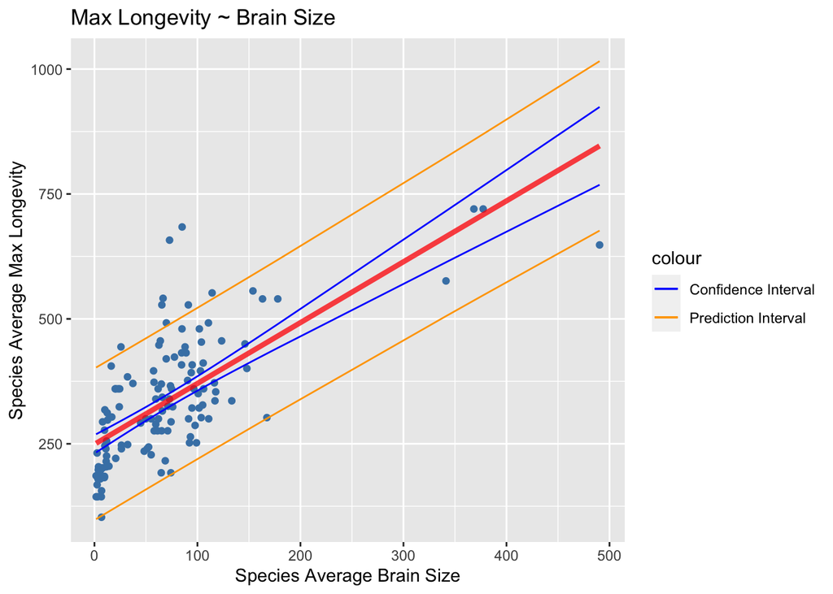

```r
kamilar <- kamilar %>% mutate(lwrCI90 = kamilarconf90$lwr, # i like tidyverse mroe than base r,
                              # add all our dudes to the same df
                              uprCI90 = kamilarconf90$upr,
                              lwrpred90 = kamilarpred90$lwr,
                              uprpred90 = kamilarpred90$upr,
                              loglwrCI90 = logkamilarconf90$lwr,
                              loguprCI90 = logkamilarconf90$upr,
                              loglwrpred90 = logkamilarpred90$lwr,
                              loguprpred90 = logkamilarpred90$upr)

colors <- c("Confidence Interval" = "blue", "Prediction Interval" = "orange") # make color key


kamilar %>% ggplot(aes(x = Brain_Size_Species_Mean, y = MaxLongevity_m)) + # plot for non log
  geom_point(color = "steelblue") + # this is the best base R color <3
  geom_line(aes(x = Brain_Size_Species_Mean, y = linear_model),
            color = "red", size = 1.5, alpha = 0.75) +
  geom_line(aes(x = Brain_Size_Species_Mean, y = lwrCI90, color = "Confidence Interval")) +
  geom_line(aes(x = Brain_Size_Species_Mean, y = uprCI90, color = "Confidence Interval")) +
  geom_line(aes(x = Brain_Size_Species_Mean, y = lwrpred90, color = "Prediction Interval")) +
  geom_line(aes(x = Brain_Size_Species_Mean, y = uprpred90, color = "Prediction Interval")) +
  xlab("Species Average Brain Size") +
  ylab("Species Average Max Longevity") +
  ggtitle("Max Longevity ~ Brain Size") +
  scale_color_manual(values = colors)
```

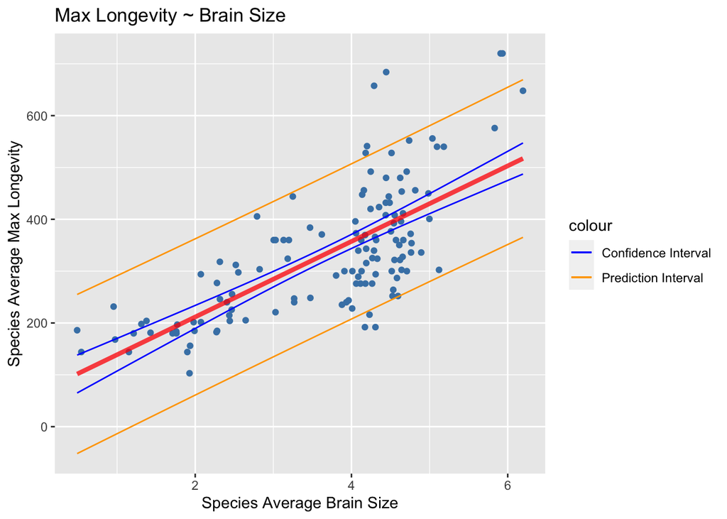

```r
kamilar %>% ggplot(aes(x = log(Brain_Size_Species_Mean), y = MaxLongevity_m)) + # plot for non log
  geom_point(color = "steelblue") + # this is the best base R  color <3
  geom_line(aes(x = log(Brain_Size_Species_Mean), y = log_linear_model),
            color = "red", size = 1.5, alpha = 0.75) +
  geom_line(aes(x = log(Brain_Size_Species_Mean), y = loglwrCI90, color = "Confidence Interval")) +
  geom_line(aes(x = log(Brain_Size_Species_Mean), y = loguprCI90, color = "Confidence Interval")) +
  geom_line(aes(x = log(Brain_Size_Species_Mean), y = loglwrpred90, color = "Prediction Interval")) +
  geom_line(aes(x = log(Brain_Size_Species_Mean), y = loguprpred90, color = "Prediction Interval")) +
  xlab("Species Average Brain Size") +
  ylab("Species Average Max Longevity") +
  ggtitle("Max Longevity ~ Brain Size") +
  scale_color_manual(values = colors)
```

Point estimates!

```r
norm_pt_estim <- predict(kamilarmodel, newdata = data.frame(Brain_Size_Species_Mean = c(800)),
                       interval = "conf", level = 0.95); norm_pt_estim # we're going to do point esitmates
```

```
##        fit     lwr      upr
## 1 1223.345 1063.45 1383.239
```

```r
log_pt_estim <- predict(log_kamilar, newdata = data.frame(Brain_Size_Species_Mean = c(800)),
                        interval = "conf", level = 0.95); log_pt_estim
```

```
##        fit      lwr      upr
## 1 552.9592 511.4809 594.4376
```

The log transformed point estimate is easily more plausible than the non-transformed linear model. Of the two models, the log transformed model is much preferred since the non-transformed data appears nonlinear (it looks like a logarithmic function).